# Conditional Probability

Author

Mike Kimmell

Published

February 17, 2025

**Abstract:**

This is a technical blog post of **both** an HTML file *and* .qmd file hosted on GitHub pages.

# 1. Setup

**Step Up Code:**

```r
sh <- suppressPackageStartupMessages
sh(library(tidyverse))
sh(library(caret))
sh(library(fastDummies))
sh(library(naivebayes))
sh(library(tidytext))
wine <- readRDS(gzcon(url("https://github.com/cd-public/D505/raw/master/dat/pinot.rds")))
```

# 2. Conditional Probability

Calculate the probability that a Pinot comes from Burgundy given it has the word ‘fruit’ in the description.

$$P({\rm Burgundy}~|~{\rm Fruit})$$

```r
wino <- wine %>%
  mutate(year_f = as.factor(year)) %>%
  mutate(fruit = str_detect(description,"fruit"))

burgundy_and_fruity <- nrow(filter(wino, province=="Burgundy" & fruit))/nrow(wino)
fruity <- nrow(filter(wino, fruit))/nrow(wino)
burgundy_and_fruity/fruity
```

```
[1] 0.2196038
```

> The probability of Burgundy given Fruit, is roughly 22%.

# 3. Naive Bayes Algorithm

We train a naive bayes algorithm to classify a wine’s province using: 1. An 80-20 train-test split. 2. Three features engineered from the description 3. 5-fold cross validation.

We report Kappa after using the model to predict provinces in the holdout sample.

```r
winy <- wine %>%
  mutate(year_f = as.factor(year)) %>%
  mutate(fruit = str_detect(description,"fruit")) %>%
  mutate(sour = str_detect(description,"sour")) %>%
  mutate(tannins = str_detect(description,"tannins")) %>%
  select(-description, year)

wine_index <- createDataPartition(winy$province, p = 0.80, list = FALSE)
train <- winy[ wine_index, ]
test <- winy[-wine_index, ]

fit <- train(province ~ .,
             data = train,
             method = "naive_bayes",
             metric = "Kappa",
             trControl = trainControl(method = "cv", number=5))

confusionMatrix(predict(fit, test),factor(test$province))
```

```
Confusion Matrix and Statistics

                   Reference
Prediction          Burgundy California Casablanca_Valley Marlborough New_York
  Burgundy                43          2                 0           0        0
  California             117        740                17          20        9
  Casablanca_Valley        3          1                 0           1        1
  Marlborough              6          2                 0           0        2
  New_York                69         46                 9          24       14
  Oregon                   0          0                 0           0        0
                   Reference
Prediction          Oregon
  Burgundy               8
  California           344
  Casablanca_Valley     40
  Marlborough           11
  New_York             144
  Oregon                 0

Overall Statistics

               Accuracy : 0.4764
                 95% CI : (0.4522, 0.5006)
    No Information Rate : 0.4728
    P-Value [Acc > NIR] : 0.3937

                  Kappa : 0.1812

 Mcnemar's Test P-Value : <2e-16

Statistics by Class:

                     Class: Burgundy Class: California Class: Casablanca_Valley
Sensitivity                  0.18067            0.9355                  0.00000
Specificity                  0.99303            0.4252                  0.97207
Pos Pred Value               0.81132            0.5934                  0.00000
Neg Pred Value               0.87963            0.8803                  0.98402
Prevalence                   0.14226            0.4728                  0.01554
Detection Rate               0.02570            0.4423                  0.00000
Detection Prevalence         0.03168            0.7454                  0.02750
Balanced Accuracy            0.58685            0.6803                  0.48604
                     Class: Marlborough Class: New_York Class: Oregon
Sensitivity                     0.00000        0.538462         0.000
Specificity                     0.98710        0.822708         1.000
Pos Pred Value                  0.00000        0.045752           NaN
Neg Pred Value                  0.97276        0.991222         0.673
Prevalence                      0.02690        0.015541         0.327
Detection Rate                  0.00000        0.008368         0.000
Detection Prevalence            0.01255        0.182905         0.000
Balanced Accuracy               0.49355        0.680585         0.500
```

# 4. Frequency Differences

We find the three words that most distinguish New York Pinots from all other Pinots.

```r
df <- wine %>% #mostly pulled from the lecture slides, this block gets us our words
  unnest_tokens(word, description) %>%
  anti_join(stop_words) %>%
  filter(!(word %in% c("wine","pinot","drink","noir","vineyard","palate","notes","flavors","bottling"))) %>%
  count(id, word)%>%
  group_by(id) %>%
  mutate(freq = n/sum(n)) %>%
  mutate(exists = (n>0)) %>%
  ungroup() %>%
  group_by(word)%>%
  mutate(total = sum(n)) %>%
  left_join(select(wine, id, province), by = "id")%>%
  count(province, word) %>%
  group_by(province) %>%
  arrange(province, desc(n))
temp_df <- df %>% #I wanted to get word frequency, and I couldn't remember how to do a window function in R
  group_by(province) %>% #So, these next few lines do it the long way around
  summarize(
    tot = sum(n)
  )
df2 <- df %>%
  left_join(select(temp_df,province,tot), by = "province")

df2 <- df2 %>%
  mutate(freq = (n/tot)*100)

#Now we take a look at the top New York words to see what they are
df2 %>% filter (province == 'New_York') %>%
  head(n=10)
```

```
# A tibble: 10 × 5
# Groups:   province [1]
   word         province     n   tot  freq
   <chr>        <chr>    <int> <int> <dbl>
 1 cherry       New_York   105  2940 3.57
 2 tannins      New_York    76  2940 2.59
 3 finish       New_York    64  2940 2.18
 4 acidity      New_York    50  2940 1.70
 5 red          New_York    49  2940 1.67
 6 black        New_York    38  2940 1.29
 7 concentrated New_York    34  2940 1.16
 8 ripe         New_York    31  2940 1.05
 9 bright       New_York    30  2940 1.02
10 brisk        New_York    28  2940 0.952
```

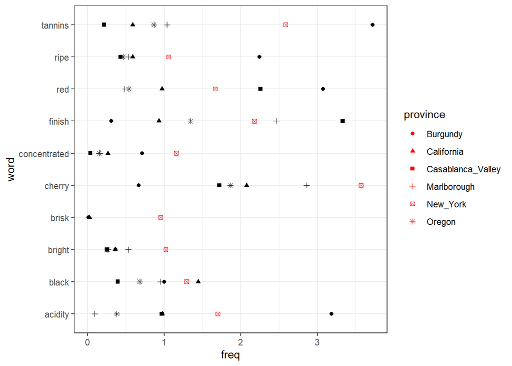

```r
dfny <- df2 %>% filter(province == "New_York" & word %in% c("cherry","tannins","finish","acidity","red","black",
                            "concentrated","ripe","bright","brisk"))
#Filter df2 down to just these words and visualize
df2 %>% filter (province != "New_York" & word %in% c("cherry","tannins","finish","acidity","red","black",
                            "concentrated","ripe","bright","brisk")) %>%
  ggplot(aes(word,freq, shape=province)) +
    geom_point() +
    geom_point(data=dfny, color="red") +
    coord_flip() +
    theme_bw()
```

> Using the simple plot above, we can see that New York has 4 of its most used words used more frequently than the other provinces. Most frequently, it uses the word ‘cherry’ and while less frequent in its own usage of words, it uses the words ‘concentrated’, ‘bright’, and ‘brisk’ more often than the other provinces.